## Newton-Raphson method

This is an iterative method for finding points of inflection of a function, e.g. $f(x)$.

The algorithm procedes using the following steps:

1. Take an intitial guess at the solution, e.g. $x_n$
2. Approximate $f(x)$ using a second order Taylor series expansion about $x_n$ (i.e. a quadratic approxiation)
3. Find the point of inflection of the quadratic approxiation (i.e. find the root of the first derivative of the quadratic approximation)
4. Update the solution

Iterate through steps 2-4 until the estimates converge.

In general terms, consider the function $f(x)$.

The second order Taylor series approximation is,

$$f(x) \approx f(x_0) + f'(x_0)(x-x_0) + \frac{f''(x_0)}{2}(x-x_0)^2$$

To find the point of inflection of this quadratic function we take the first derivative,

$$\frac{d}{dx} f(x) \approx f'(x_0) + f''(x_0)(x-x_0)$$

and solve it for x,

$$f'(x_0) + f''(x_0)(x-x_0) = 0$$

$$\implies x = x_0 - \frac{f'(x_0)}{f''(x_0)}$$

The general update function is,

$$x_{n+1} = x_n - \frac{ f'(x_n) }{ f''(x_n) }$$

### Finding roots

Notice that you can also think of the algorthim as finding the root of $f'(x_n)$.

In general, if you wanted to find the root of $g(x)$ you would use the update function,

$$x_{n+1} = x_n - \frac{ g(x_n) }{ g'(x_n) }$$

### Example

Consider a simple polynomial function,

$$f(x) = 3000 - 100x - 25x^2 - 0.25x^4$$

which has fist and second derivatives,

$$f'(x) = -100 - 50x - x^3$$

$$f''(x) = -50 - 3x^2$$

The plots on the left hand side below show how $f(x)$ can be maximised using the Newton-Raphson method.

Equivalently, the plots on the right hand side below show how the root of $f'(x)$ can found using the Newton-Raphson method.

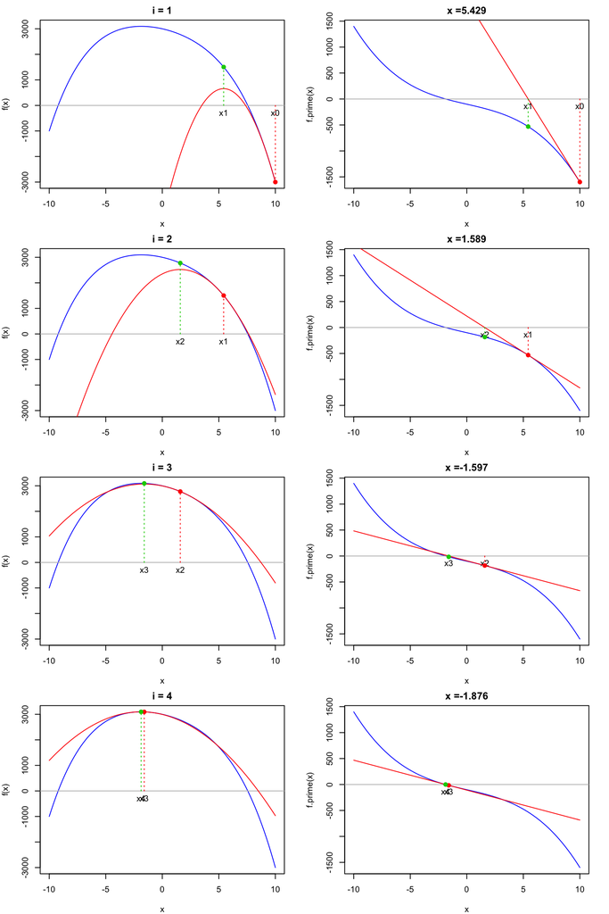

```r
# Helper functions
f = function(x) 3000 - 100*x - 25*x^2 - 0.25*x^4
f.prime = function(x) -100 - 50*x - x^3
f.prime2 = function(x) -50 - 3*x^2
update = function(x) x - f.prime(x) / f.prime2(x)
quadratic = function(a) curve(f(a) + f.prime(a)*(x-a) + f.prime2(a)/2*(x-a)^2, col=2, add = TRUE)
linear = function(a) curve(f.prime(a) + f.prime2(a)*(x-a), col=2, add = TRUE)

xn = 10 # initial guess

par(mfrow = c(4,2), mar = c(4,4,2,2), oma = c(0,0,0,0))

for(i in 1:4){

    # update
    xnew = update(xn)

    # f(x)
    curve(f(x), xlim = c(-10, 10), col = 4)
    abline(h=0, col = "grey")

    # currential guess
    text(xn, 0, paste("x", i-1, sep=""), pos = 1)
    lines(c(xn, xn), c(0, f(xn)), lty = 3, col = 2)
    points(xn, f(xn), pch = 19, col = 2)
    quadratic(xn)

    lines(c(xnew, xnew), c(0, f(xnew)), lty = 3, col = 3)
    text(xnew, 0, paste("x", i, sep=""), pos = 1)
    points(xnew, f(xnew), pch = 19, col = 3)

    title(paste("i =", i))

    # f'(x)
    curve(f.prime(x), xlim = c(-10, 10), col = 4)
    abline(h=0, col = "grey")

    # currential guess
    text(xn, 0, paste("x", i-1, sep=""), pos = 1)
    lines(c(xn, xn), c(0, f.prime(xn)), lty = 3, col = 2)
    points(xn, f.prime(xn), pch = 19, col = 2)
    linear(xn)

    # update
    lines(c(xnew, xnew), c(0, f.prime(xnew)), lty = 3, col = 3)
    text(xnew, 0, paste("x", i, sep=""), pos = 1)
    points(xnew, f.prime(xnew), pch = 19, col = 3)

    title(paste("x =", round(xnew,3), sep=""))

    xn = xnew

}
```

And so on, and so on…

Here’s a function that does the same thing and judges convergence according to some tolerance.

```r
nr = function(x0, tol = 1e-5){
    continue = TRUE
    counter = 0
    while(continue){
        x1 = update(x0)
        continue = abs(x1 - x0) > tol
        x0 = x1
        counter = counter + 1
    }
    cat(counter, "iterations")
    return(x1)
}
nr(10)
```

```
## 6 iterations
```

```
## [1] -1.869352
```